# GED16/AO808: Análise de Regressão

AULA06: Prática

Professora: Denise B. Ferrari

1o. semestre/2021

### Introdução

“[Infecção hospitalar](https://www.prefeitura.sp.gov.br/cidade/secretarias/saude/vigilancia_em_saude/infeccao_hospitalar/index.php?p=6445) é uma infecção adquirida após a admissão do paciente na unidade hospitalar e pode se manifestar durante a internação ou após a alta. Pela sua gravidade e aumento do tempo de internação do paciente, é causa importante de morbidade e mortalidade, caracterizando-se como problema de saúde pública.”

Os dados disponíveis no arquivo `data/SCENIC.txt` foram coletados pelo CDC (US Center for Disease Control), no âmbito do [Projeto SCENIC](https://doi.org/10.1093/oxfordjournals.aje.a112928). O principal objetivo do projeto era determinar se programas de vigilância e controle foram capazes de reduzir as taxas de infecção hospitalar. Os dados referem-se a uma amostra de 113 hospitais selecionados a partir de um conjunto de 338 hospitais avaliados. Cada linha do conjunto de dados contém uma identificação (1-113) e fornece informação a respeito de 11 variáveis para um único hospital. Os dados apresentados referem-se ao período de 1975-1976.

As 12 variáveis são:

1. `IDnumber`: 1-113 (identificação do hospital)
2. `LengthStay`: período de internação médio de todos os pacientes no hospital (em dias)
3. `Age`: idade média dos pacientes (anos)
4. `InfectRisk`: risco de infecção, calculado como a probabilidade média estimada de contrair infecção no hospital (em %)
5. `CultRatio`: razão do número de culturas realizadas pelo número de pacientes sem sintomas de infecção hospitalar, vezes 100
6. `XrayRatio`: razão do número de raios-X realizados pelo número de pacientes sem sintomas de pneumonia, vezes 100
7. `NBeds`: número médio de leitos do hospital, durante o período avaliado
8. `MedSchool`: afiliação a alguma Escola de Medicina (1=Sim, 2=Não)
9. `Region`: região geográfica (1=NE, 2=NC, 3=S, 4=W)
10. `DailyCensus`: número médio de pacientes no hospital por dia, durante o período avaliado
11. `NNurses`: número médio de enfermeiros no hospital
12. `Facilities`: percentual de 35 serviços providos pelo hospital

Acredita-se que o período médio de internação de um paciente `LengthStay` (variável de resposta) possa ser previsto a partir do risco de infecção hospitalar, bem como outras características do hospital e de procedimentos de rotina realizados.

### Análise Exploratória de Dados

Conduza a análise exploratória da massa de dados `SCENIC`, a fim de compreender suas características principais.

```r
rm(list=ls())
scenic <- read.table("data/SCENIC.txt", header = FALSE)
```

### PARTE 1: Regressão Linear Simples

1. Assuma que um modelo de regressão linear simples é adequado para modelar a relação da variável de resposta `LengthStay` a cada uma das variáveis explicativas `InfectRisk`, `Facilities` e `XrayRatio`.
- Construa um modelo de regressão para cada um desses pares de variáveis;
- Construa gráficos de dispersão (separados) com as retas de regressão ajustadas para cada caso;
- Calcule o MSE para cada modelo. Que variável explicativa produz menor variabilidade em torno da reta de regressão ajustada?
- Utilizando R<sup>2</sup> como critério, qual das variáveis explicativas contribui para a maior redução na variabilidade da resposta `LengthStay`?
2. Para cada região geográfica, construa um modelo de regressão para a variável de resposta `LengthStay` em função de `InfectRisk`. Assuma que o modelo de 1a. ordem é adquado para modelar essas relações. Obtenha os modelos de regressão ajustados.
- As funções de regressão estimadas são semelhantes para as quatro regiões? Discuta.
- Calcule o MSE para cada região. A variabilidade em torno da reta de regressão ajustada é semelhante para as quatro regiões?
- Construa intervalos de confiança 95% para o coeficiente angular da reta de regressão para cada região. As retas de regressão para diferentes regiões parecem ter mesma inclinação? O que se pode concluir?
- Construa intervalos de confiança para a resposta esperada correspondendo a `InfectRisk = 5`, para cada região. O que se pode concluir?
- Construa intervalos de previsão para um novo hospital em cada região que tenha `InfectRisk = 5`. O que se pode concluir?

### Diagnóstico

1. Para cada um dos três modelos de regressão ajustados no item (1) da seção anterior, realize o diagnóstico através da análise dos resíduos e apresente um resumo de suas conclusões. O modelo de regressão linear simples clássico é adequado a alguma das situações investigadas?
2. Ajuste um modelo de regressão linear simples para a variável `LengthStay` como função de `InfectRisk` após excluir as observações 47 (X = 6.5 e Y = 19.56) e 112 (X = 5.9 e Y = 17.94). Obtenha intervalos de previsão de 95% de confiança para novas observações que apresentam valores da variável explicativa iguais a 6.5 e 5.9. As observações eliminadas encontram-se nos limites dos intervalos de previsão obtidos? Discuta o significado dos resultados obtidos.
3. Para os modelos considerando cada região geográfica separadamente no item (2) da seção anterior, realize o diagnóstico através da análise dos resíduos. Todas as regiões aparentam ter mesma variância dos erros? Que conclusões é possível obter a partir da análise?

### PARTE 2: Regressão Linear Múltipla

Dois modelos foram propostos para prever o período médio de internação de um paciente (`LengthStay`):

**Modelo I**: utiliza como variáveis explicativas `Age`, `InfectRisk` e `Facilities`

**Modelo II**: utiliza como variáveis explicativas `NBeds`, `InfectRisk` e `Facilities`

1. Construa a matriz de gráficos de dispersão, bem como a matriz de correlação para cada modelo proposto. Interprete os resultados obtidos.
2. Para cada modelo, ajuste um modelo de regressão de 1a. ordem com as três variáveis explicativas consideradas. Discuta os resultados obtidos.
3. Realize o diagnóstico dos modelos. É possível identificar um modelo que seja mais adequado aos dados?
4. Para cada região geográfica, construa um modelo de regressão de 1a. ordem para `InfectRisk` como função das variáveis `Age`, `CultRatio`, `DailyCensus` e `Facilities`.
   - Comente sobre os resultados obtidos para os modelos ajustados.
   - As funções de regressão estimadas são semelhantes nas quatro regiões? Discuta.
   - Analise os valores de MSE e $R^2_aj$ para cada modelo Essas medidas são semelhantes para as quatro regiões? Discuta.
   - Realize o diagnóstico dos modelos construídos. Interprete os gráficos e os resultados obtidos.

### Análise de Somas de Quadrados Extras

Decidiu-se prever o período médio de internação de um paciente (`LengthStay`), em função das variáveis `Age` e `InfectRisk`. A questão agora é se a inclusão de outra variável explicativa adicional no modelo seria útil e, em caso positivo, qual delas seria mais útil. Foram consideradas as seguintes variáveis extras: `CultRatio`, `DailyCensus`, `NNurses` e `Facilities`.

Assuma que um modelo de regressão linear múltipla de 1a. ordem é adequado.

1. Analise as somas de quadrados extras e discuta qual das quatro variáveis explicativas candidatas é a melhor inclusão.
2. Conduza um teste utilizando a estatística F parcial (com nível de significância 5%) para decidir se a variável escolhida no item anterior é útil no modelo de regressão que já contém `Age` e `InfectRisk`. Descreva as alternativas, a regra de decisão e a conclusão do teste. A estatística F parcial correspondente para as outras três candidatas teria valor tão elevado quando a da variável escolhida? Discuta.

### Multicolinearidade

Um modelo de regressão de 1a. ordem para `LengthStay` em função de `Age`, `XrayRatio`, `DailyCensus` é construído com base nas observações 57-113. Com base na matriz de gráficos de dispersão, matriz de correlação e VIFs, analise se há indícios de problemas sérios de multicolinearidade. Justifique sua análise.

### PARTE 3: Construção do Modelo

Ajuste um modelo quadrático relacionando as variáveis `NNurses` (resposta) e `Facilities` (variável explicativa).

1. Através de análise dos resíduos analise se o modelo de 2a. ordem construído parece se ajustar bem aos dados.
2. Analise o coeficiente de determinação ajustado para o modelo de 2a. ordem obtido no item anterior e compare com o coeficiente de determinação simples obtido para um modelo de 1a. ordem para as mesmas variáveis. Qual o efeito da adição do termo quadrático no modelo para o coeficiente de determinação? O que isso significa?
3. Conduza um teste de hipóteses para avaliar se o termo quadrático pode ser eliminado do modelo de regressão, para o nível de significância de 1%. Explicite as alternativas, a regra de decisão e a conclusão do teste.

Agora, vamos construir modelos de regressão para a variável `InfectRisk` (resposta) como função das variáveis explicativas `LengthStay`, `Age`, `XrayRatio` e `MedSchool`.

4. Ajuste um modelo de regressão 1a. ordem.
5. Estime o efeito de `MedSchool` em `InfectRisk` utilizando um intervalo de confiança 98%. Interprete o resultado obtido.
6. Sugeriu-se que o efeito de `MedSchool` em `InfectRisk` possa interagir com os efeitos das variáveis `Age` e `XrayRatio`. Adicione ao modelo anterior os termos de interação adequados, ajuste o modelo modificado e teste a significância dos termos de interação para $\alpha = 0.1$. Explicite as hipóteses consideradas, a regra de decisão e a conclusão do teste.

Considere a construção de um modelo de regressão de 1a. ordem para a variável `LengthStay` como função de `Age`, `CultRatio`, `DailyCensys`, `Facilities` e `Region`.

7. Teste se a variável `CultRatio` pode ser eliminada do modelo para o nível de significância de 5%. Explicite as alternativas, a regra de decisão e a conclusão do teste.
8. Examine se existe diferença nos efeitos na resposta `LengthStay` para hospitais em diferentes regiões. Que procedimento formal deve ser utilizado para avaliar essa questão?

```r
rm(list = ls())
scenic <- read.table("data/SCENIC.txt")
colnames(scenic) <- c("IDnumber","LengthStay","Age","InfectRisk","CultRatio","XrayRatio","NBeds","MedSchool","Region","DailyCensus","NNurses","Facilities")

str(scenic)
```

```
## 'data.frame':    113 obs. of  12 variables:
##  $ IDnumber   : int  1 2 3 4 5 6 7 8 9 10 ...
##  $ LengthStay : num  7.13 8.82 8.34 8.95 11.2 ...
##  $ Age        : num  55.7 58.2 56.9 53.7 56.5 50.9 57.8 45.7 48.2 56.3 ...
##  $ InfectRisk : num  4.1 1.6 2.7 5.6 5.7 5.1 4.6 5.4 4.3 6.3 ...
##  $ CultRatio  : num  9 3.8 8.1 18.9 34.5 21.9 16.7 60.5 24.4 29.6 ...
##  $ XrayRatio  : num  39.6 51.7 74 122.8 88.9 ...
##  $ NBeds      : int  279 80 107 147 180 150 186 640 182 85 ...
##  $ MedSchool  : int  2 2 2 2 2 2 2 1 2 2 ...
##  $ Region     : int  4 2 3 4 1 2 3 2 3 1 ...
##  $ DailyCensus: int  207 51 82 53 134 147 151 399 130 59 ...
##  $ NNurses    : int  241 52 54 148 151 106 129 360 118 66 ...
##  $ Facilities : num  60 40 20 40 40 40 40 60 40 40 ...
```

```r
scenic$MedSchool[scenic$MedSchool == 2 ] <- 0
scenic$IDnumber <- as.factor(scenic$IDnumber)
scenic$MedSchool <- as.factor(scenic$MedSchool)
scenic$Region <- as.factor(scenic$Region)

attach(scenic)

data1 <- data.frame(NNurses = NNurses, Facilities = Facilities)

attach(data1)
```

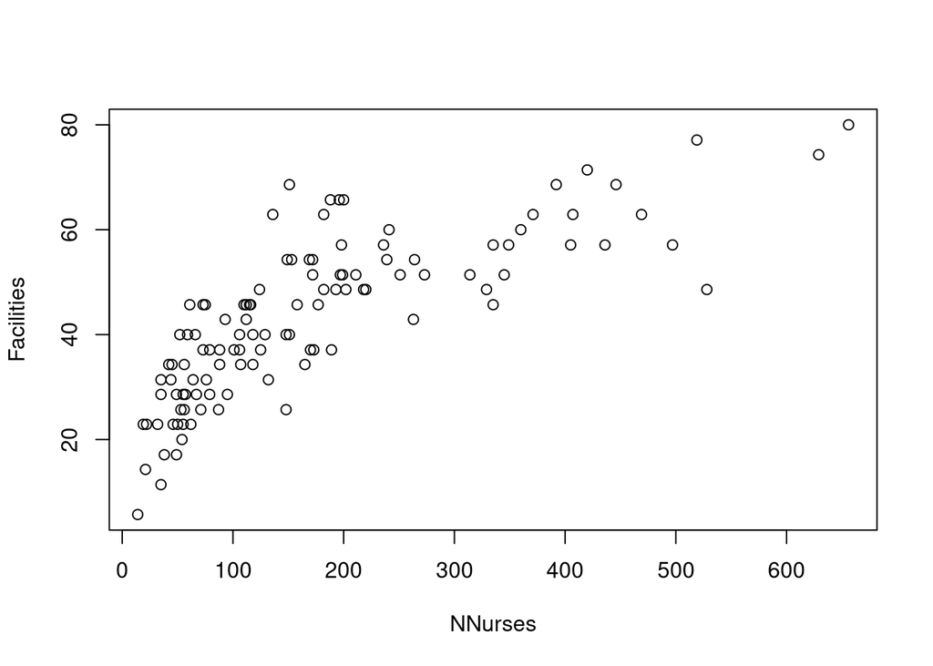

```r
plot(data1)
```

```r
str(scenic)
```

```
## 'data.frame':    113 obs. of  12 variables:
##  $ IDnumber   : Factor w/ 113 levels "1","2","3","4",..: 1 2 3 4 5 6 7 8 9 10 ...
##  $ LengthStay : num  7.13 8.82 8.34 8.95 11.2 ...
##  $ Age        : num  55.7 58.2 56.9 53.7 56.5 50.9 57.8 45.7 48.2 56.3 ...
##  $ InfectRisk : num  4.1 1.6 2.7 5.6 5.7 5.1 4.6 5.4 4.3 6.3 ...
##  $ CultRatio  : num  9 3.8 8.1 18.9 34.5 21.9 16.7 60.5 24.4 29.6 ...
##  $ XrayRatio  : num  39.6 51.7 74 122.8 88.9 ...
##  $ NBeds      : int  279 80 107 147 180 150 186 640 182 85 ...
##  $ MedSchool  : Factor w/ 2 levels "0","1": 1 1 1 1 1 1 1 2 1 1 ...
##  $ Region     : Factor w/ 4 levels "1","2","3","4": 4 2 3 4 1 2 3 2 3 1 ...
##  $ DailyCensus: int  207 51 82 53 134 147 151 399 130 59 ...
##  $ NNurses    : int  241 52 54 148 151 106 129 360 118 66 ...
##  $ Facilities : num  60 40 20 40 40 40 40 60 40 40 ...
```

```r
data1
```

| NNurses | Facilities |
| --- | --- |
| 241 | 60.0 |
| 52 | 40.0 |
| 54 | 20.0 |
| 148 | 40.0 |
| 151 | 40.0 |
| 106 | 40.0 |
| 129 | 40.0 |
| 360 | 60.0 |
| 118 | 40.0 |
| 66 | 40.0 |

[output cut: 103 more lines]

O modelo da regressão me Segunda ordem para variável ‘NNurses’ como função de ‘Facilities’ pode ser descrito como: $E[NNurses] = \beta_0 + \beta_1 Facilities + \beta_2 Facilities^2$

Vamos verificar a correlação entre a variável explicativa Facilities e Facilities^2. Caso a correlação seja elevada, é desejável centralizar a variável explicativa quantitativa, fazendo Facilities.c = Facilities - mean(Facilities):

```r
cor(Facilities,Facilities^2)
```

```
## [1] 0.9776689
```

Essa correlação é elevada, portanto iremos centralizar a variável explicativa:

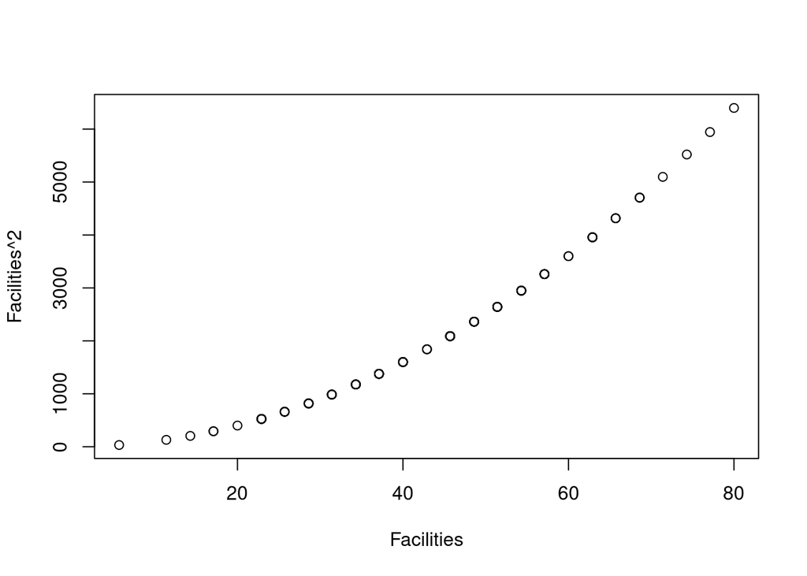

```r
plot(Facilities, Facilities^2)
```

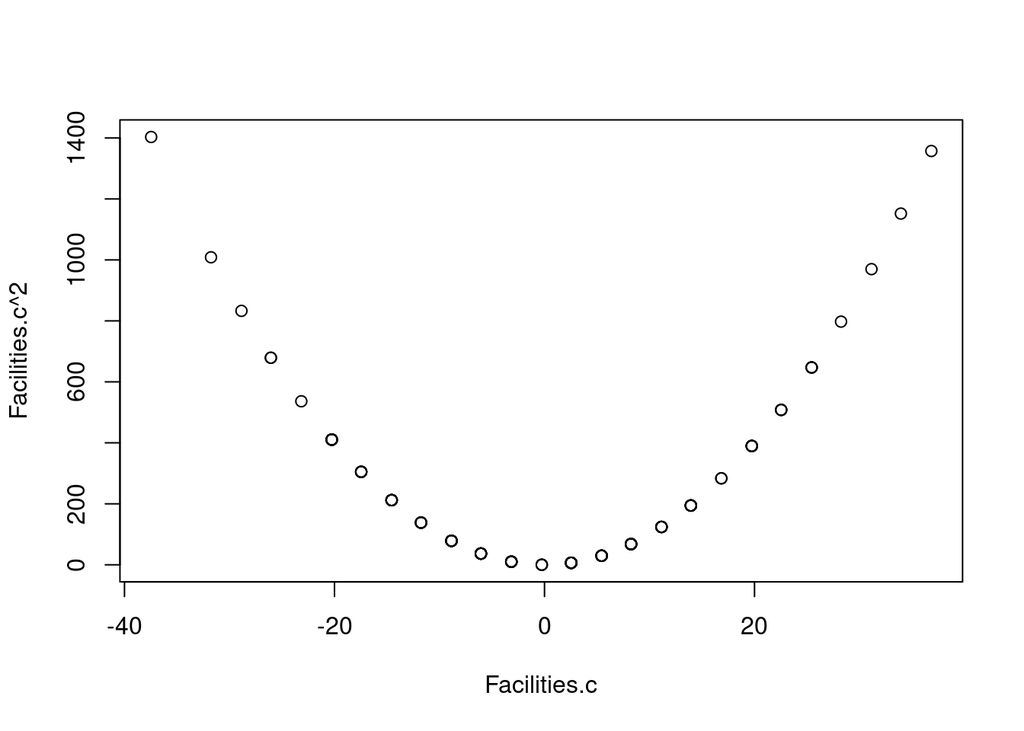

```r
Facilities.c <- Facilities - mean(Facilities)
plot(Facilities.c, Facilities.c^2)
```

Resultado Centralizado, agora verificaremos sua correlação resultante:

```r
cor(Facilities.c, Facilities.c^2)
```

```
## [1] 0.05883963
```

A centralização foi adequada, uma vez que a correlação resultante atingiu patamares muito próximos de 0, indicando forte independência.

Os resultados para o modelo não ajustado são:

```r
m.quant_original <- lm(NNurses ~ Facilities + I(Facilities^2))
summary(m.quant_original)
```

```
##
## Call:
## lm(formula = NNurses ~ Facilities + I(Facilities^2))
##
## Residuals:
##     Min      1Q  Median      3Q     Max
## -244.32  -39.42   -4.55   26.48  336.48
##
## Coefficients:
##                 Estimate Std. Error t value Pr(>|t|)
## (Intercept)     33.54823   51.41432   0.653  0.51544
## Facilities      -1.66613    2.43463  -0.684  0.49519
## I(Facilities^2)  0.10116    0.02723   3.716  0.00032 ***
## ---
## Signif. codes:  0 '***' 0.001 '**' 0.01 '*' 0.05 '.' 0.1 ' ' 1
##
## Residual standard error: 82.31 on 110 degrees of freedom
## Multiple R-squared:  0.6569, Adjusted R-squared:  0.6507
## F-statistic: 105.3 on 2 and 110 DF,  p-value: < 2.2e-16
```

O modelo ajustado, considerando a variável explicativa centralizada:

```r
m.quant <- lm(NNurses ~ Facilities.c + I(Facilities.c^2))
summary(m.quant)
```

```
##
## Call:
## lm(formula = NNurses ~ Facilities.c + I(Facilities.c^2))
##
## Residuals:
##     Min      1Q  Median      3Q     Max
## -244.32  -39.42   -4.55   26.48  336.48
##
## Coefficients:
##                    Estimate Std. Error t value Pr(>|t|)
## (Intercept)       150.07915    9.94139  15.096  < 2e-16 ***
## Facilities.c        7.06617    0.51253  13.787  < 2e-16 ***
## I(Facilities.c^2)   0.10116    0.02723   3.716  0.00032 ***
## ---
## Signif. codes:  0 '***' 0.001 '**' 0.01 '*' 0.05 '.' 0.1 ' ' 1
##
## Residual standard error: 82.31 on 110 degrees of freedom
## Multiple R-squared:  0.6569, Adjusted R-squared:  0.6507
## F-statistic: 105.3 on 2 and 110 DF,  p-value: < 2.2e-16
```

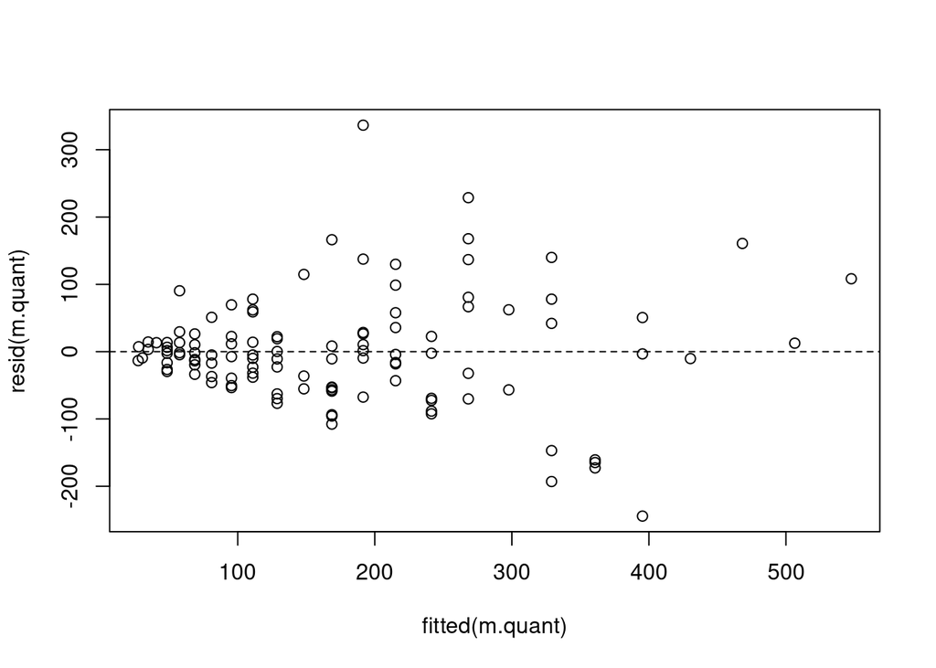

```r
plot(fitted(m.quant), resid(m.quant))
abline(h=0, lty="dashed")
```

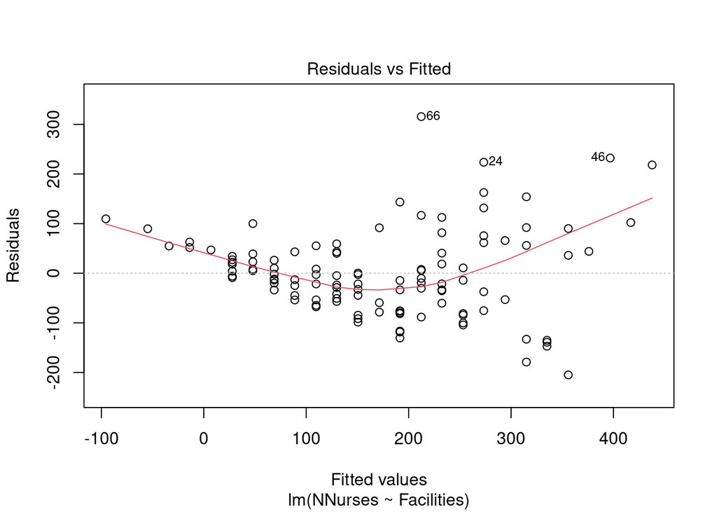

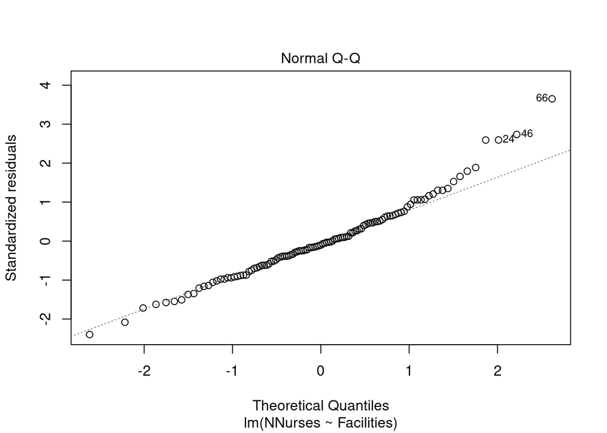

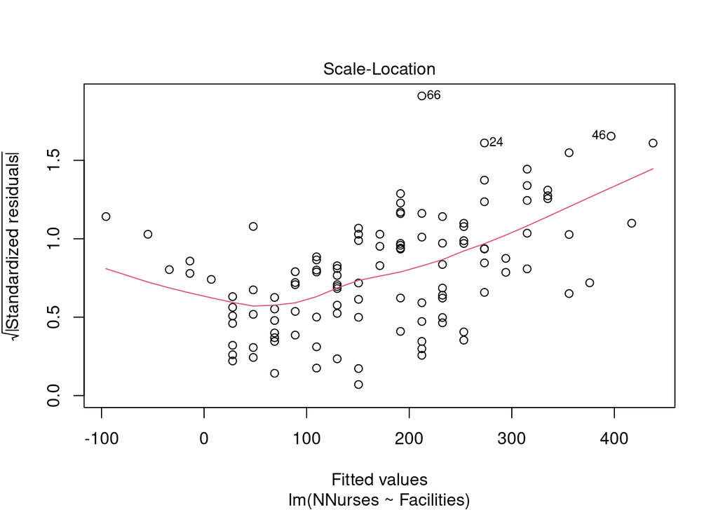

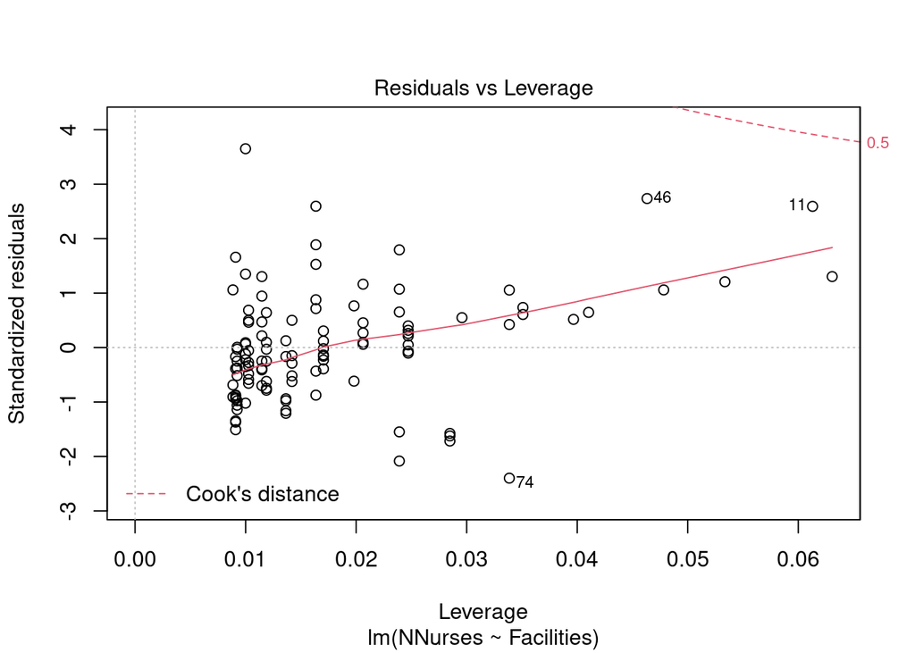

```r
m.quant_1ordem <- lm(NNurses ~ Facilities )
plot(m.quant_1ordem)
```

```r
summary(m.quant_1ordem)
```

```
##
## Call:
## lm(formula = NNurses ~ Facilities)
##
## Residuals:
##      Min       1Q   Median       3Q      Max
## -204.867  -53.837   -8.822   44.034  315.698
##
## Coefficients:
##              Estimate Std. Error t value Pr(>|t|)
## (Intercept) -136.5593    24.7132  -5.526 2.19e-07 ***
## Facilities     7.1782     0.5403  13.284  < 2e-16 ***
## ---
## Signif. codes:  0 '***' 0.001 '**' 0.01 '*' 0.05 '.' 0.1 ' ' 1
##
## Residual standard error: 86.93 on 111 degrees of freedom
## Multiple R-squared:  0.6139, Adjusted R-squared:  0.6104
## F-statistic: 176.5 on 1 and 111 DF,  p-value: < 2.2e-16
```

Observa-se que o coeficiente de determinação no modelo de segunda ordem aumentou, de forma que o ajuste passou de 0.61 para 0.65 (note que o aumento foi pouco significativo).Com isso, podemos concluir que o modelo de segunda ordem é uma melhor representação que o de primeira ordem, uma vezes que 4% a mais da variável independente é explicado na resposta.

```r
anova(m.quant)
```

|  | Df | Sum Sq | Mean Sq | F value | Pr(>F) |
| --- | --- | --- | --- | --- | --- |
| Facilities.c | 1 | 1333486.17 | 1333486.168 | 196.8368 | 2.959420e-26 |
| I(Facilities.c^2) | 1 | 93533.25 | 93533.252 | 13.8065 | 3.202726e-04 |
| Residuals | 110 | 745203.64 | 6774.579 | NA | NA |

Analisando o p-valor resultante do teste-F podemos inferir que para um nível de significância de $\alpha = 0.01$, a hipótese nula é rejeitada. Então o coeficiente de Segunda ordem é significativo.

### Segundo modelo:

```r
data2 <- data.frame(InfectRisk = InfectRisk, LengthStay = LengthStay, Age = Age, XrayRatio = XrayRatio, MedSchool = MedSchool)
m.quant2 <- lm(InfectRisk ~ LengthStay + Age + XrayRatio + MedSchool)

summary(m.quant2)
```

```
##
## Call:
## lm(formula = InfectRisk ~ LengthStay + Age + XrayRatio + MedSchool)
##
## Residuals:
##      Min       1Q   Median       3Q      Max
## -2.74669 -0.76646 -0.00283  0.77267  2.59703
##
## Coefficients:
##             Estimate Std. Error t value Pr(>|t|)
## (Intercept)  0.85738    1.32434   0.647  0.51874
## LengthStay   0.28882    0.06291   4.591  1.2e-05 ***
## Age         -0.01805    0.02411  -0.749  0.45569
## XrayRatio    0.01995    0.00577   3.458  0.00078 ***
## MedSchool1   0.28782    0.30668   0.938  0.35009
## ---
## Signif. codes:  0 '***' 0.001 '**' 0.01 '*' 0.05 '.' 0.1 ' ' 1
##
## Residual standard error: 1.085 on 108 degrees of freedom
## Multiple R-squared:  0.3681, Adjusted R-squared:  0.3447
## F-statistic: 15.73 on 4 and 108 DF,  p-value: 3.574e-10
```

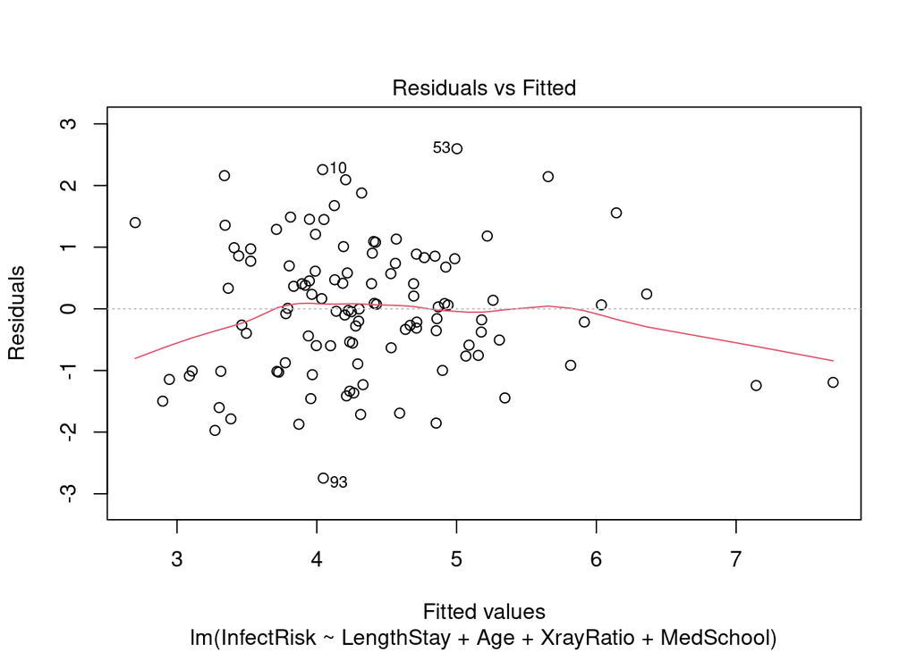

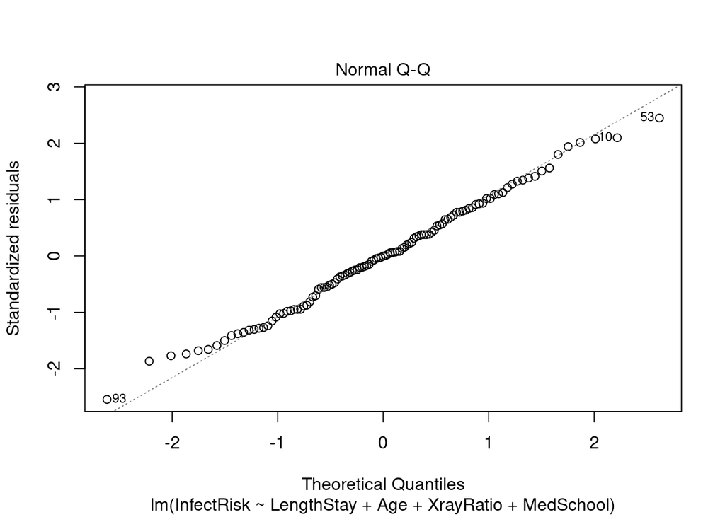

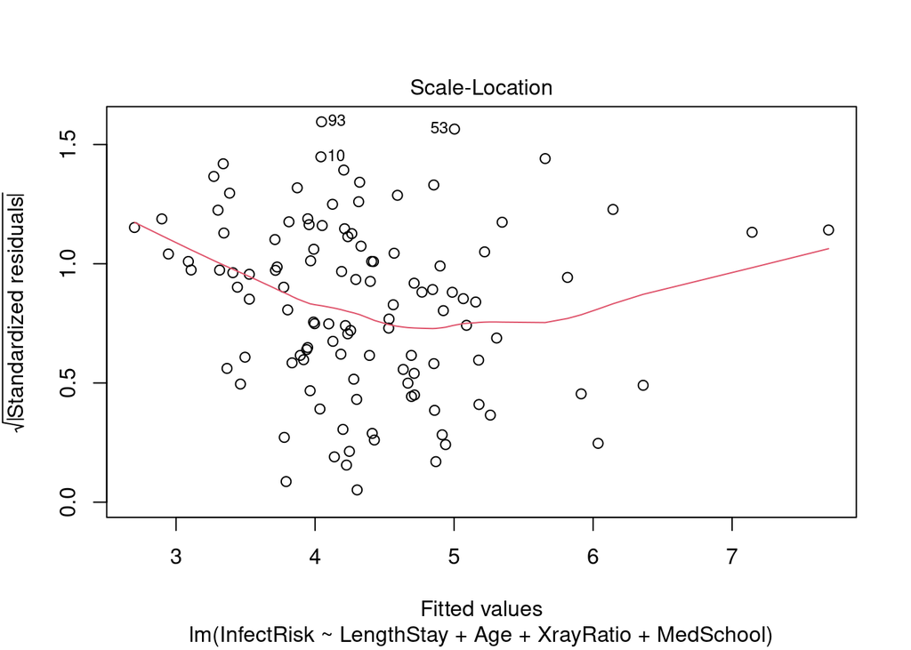

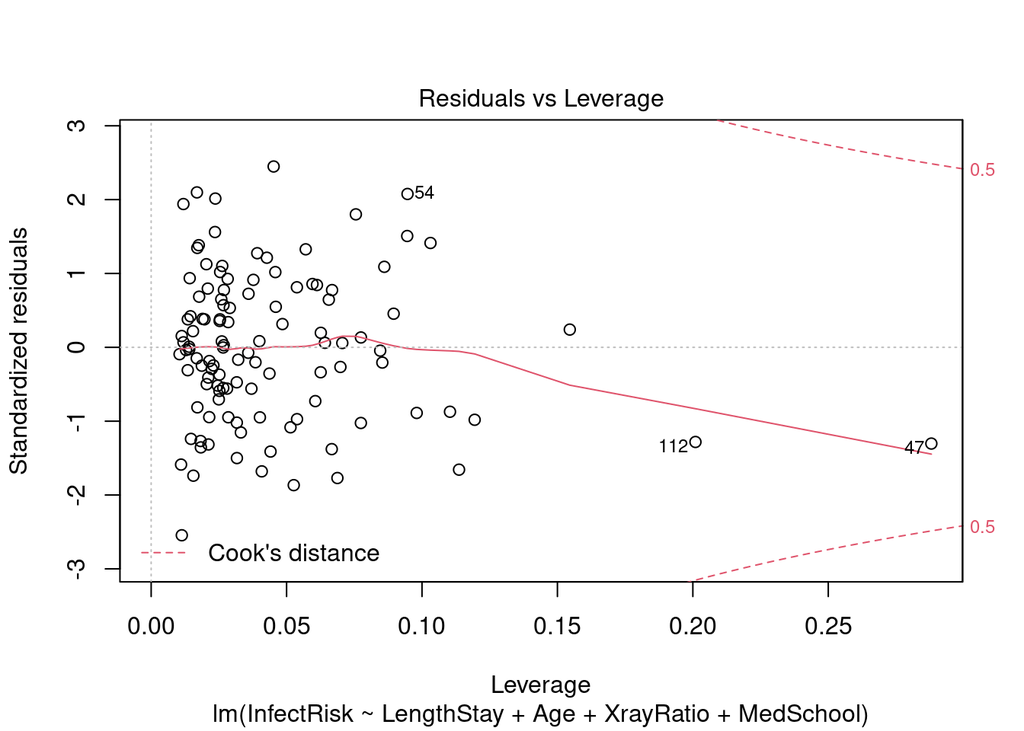

```r
plot(m.quant2)
```

```r
confint.lm(m.quant2, level=0.98)
```

```
##                      1 %       99 %
## (Intercept) -2.269869179 3.98462785
## LengthStay   0.140268153 0.43736659
## Age         -0.074992776 0.03888795
## XrayRatio    0.006325715 0.03357586
## MedSchool1  -0.436375932 1.01201157
```

Será criado um modelo completo incluindo as interações de MedSchool, Age e XRayRatio:

```r
m.all <- lm(InfectRisk ~ MedSchool + Age + XrayRatio + MedSchool * Age + MedSchool * XrayRatio)
summary(m.all)
```

```
##
## Call:
## lm(formula = InfectRisk ~ MedSchool + Age + XrayRatio + MedSchool *
##     Age + MedSchool * XrayRatio)
##
## Residuals:
##      Min       1Q   Median       3Q      Max
## -2.87461 -0.88415 -0.08378  0.77106  2.75133
##
## Coefficients:
##                       Estimate Std. Error t value Pr(>|t|)
## (Intercept)           1.194095   1.496469   0.798   0.4267
## MedSchool1           -6.570347   4.935327  -1.331   0.1859
## Age                   0.002989   0.025675   0.116   0.9075
## XrayRatio             0.035464   0.006333   5.600 1.67e-07 ***
## MedSchool1:Age        0.198174   0.098914   2.004   0.0477 *
## MedSchool1:XrayRatio -0.034644   0.014667  -2.362   0.0200 *
## ---
## Signif. codes:  0 '***' 0.001 '**' 0.01 '*' 0.05 '.' 0.1 ' ' 1
##
## Residual standard error: 1.152 on 107 degrees of freedom
## Multiple R-squared:  0.2946, Adjusted R-squared:  0.2616
## F-statistic: 8.938 on 5 and 107 DF,  p-value: 4.046e-07
```

O modelo é significativo (estatística F), pois o valor 8.938 é maior que 5. O valor do coeficiente de determinação e do coeficiente de determinação ajustado diminuiram, indicando que o modelo ajustado não explica melhor a variável independente.

```r
anova(m.all)
```

|  | Df | Sum Sq | Mean Sq | F value | Pr(>F) |
| --- | --- | --- | --- | --- | --- |
| MedSchool | 1 | 10.9355154 | 10.9355154 | 8.2371746 | 4.946938e-03 |
| Age | 1 | 0.2507315 | 0.2507315 | 0.1888634 | 6.647394e-01 |
| XrayRatio | 1 | 38.1164764 | 38.1164764 | 28.7112276 | 4.862185e-07 |
| MedSchool:Age | 1 | 2.6192179 | 2.6192179 | 1.9729253 | 1.630340e-01 |
| MedSchool:XrayRatio | 1 | 7.4067291 | 7.4067291 | 5.5791171 | 1.998407e-02 |
| Residuals | 107 | 142.0511527 | 1.3275809 | NA | NA |

```r
anova(m.quant2, m.all, test="F")
```

|  | Res.Df | RSS | Df | Sum of Sq | F | Pr(>F) |
| --- | --- | --- | --- | --- | --- | --- |
| 1 | 108 | 127.2432 | NA | NA | NA | NA |
| 2 | 107 | 142.0512 | 1 | -14.80798 | NA | NA |

Ao se gerar a tabela Anova, não foi obtido nenhum valor para o valor de F e o p-valor, por isso não é possível fazer nenhuma conclusão referente aos efeitos de interação entre variável quantitativa e categórica.

Sendo assim, o modelo final obtido é dado por:

```r
m.quant2
```

```
##
## Call:
## lm(formula = InfectRisk ~ LengthStay + Age + XrayRatio + MedSchool)
##
## Coefficients:
## (Intercept)   LengthStay          Age    XrayRatio   MedSchool1
##     0.85738      0.28882     -0.01805      0.01995      0.28782
```

### Modelo de LenghtSTay como função de Age, CultRatio, DailyCensys, Facilities e Region.

```r
data3 <- data.frame(LengthStay = LengthStay, Age = Age, CultRatio = CultRatio, DailyCensus = DailyCensus, Facilities = Facilities, Region = Region)

data3_lm <- lm(LengthStay ~ Age + CultRatio + DailyCensus + Facilities + Region)

summary(data3_lm)
```

```
##
## Call:
## lm(formula = LengthStay ~ Age + CultRatio + DailyCensus + Facilities +
##     Region)
##
## Residuals:
##     Min      1Q  Median      3Q     Max
## -2.7938 -0.7304  0.0037  0.5388  7.7231
##
## Coefficients:
##              Estimate Std. Error t value Pr(>|t|)
## (Intercept)  4.197818   1.878025   2.235 0.027519 *
## Age          0.103691   0.031459   3.296 0.001338 **
## CultRatio    0.040302   0.014303   2.818 0.005781 **
## DailyCensus  0.006600   0.001404   4.700 7.92e-06 ***
## Facilities  -0.020761   0.014369  -1.445 0.151477
## Region2     -0.959655   0.381722  -2.514 0.013454 *
## Region3     -1.516510   0.380092  -3.990 0.000123 ***
## Region4     -2.149988   0.461517  -4.659 9.37e-06 ***
## ---
## Signif. codes:  0 '***' 0.001 '**' 0.01 '*' 0.05 '.' 0.1 ' ' 1
##
## Residual standard error: 1.399 on 105 degrees of freedom
## Multiple R-squared:  0.4981, Adjusted R-squared:  0.4647
## F-statistic: 14.89 on 7 and 105 DF,  p-value: 2.283e-13
```

Ao analisar o summary do modelo criado, percebemos que os valores t são similares. Para o coeficiente CultRatio, temos que o p-valor é de 0.5781%, menor que o nível de significância de 5%, rejeitando, assim, a hipótese nula, e concluindo que CultRatio é relevante, não podendo eliminá-lo.

### Análise por região

```r
# regiao 1
data4_region1 <- subset(data3, Region == 1)
data4_region1_lm <- lm(LengthStay ~ Age + CultRatio + DailyCensus + Facilities, data = data4_region1)
summary(data4_region1_lm)
```

```
##
## Call:
## lm(formula = LengthStay ~ Age + CultRatio + DailyCensus + Facilities,
##     data = data4_region1)
##
## Residuals:
##     Min      1Q  Median      3Q     Max
## -2.8034 -1.0443 -0.1626  0.8320  6.3245
##
## Coefficients:
##              Estimate Std. Error t value Pr(>|t|)
## (Intercept) -5.381908   5.278773  -1.020  0.31855
## Age          0.284707   0.097814   2.911  0.00787 **
## CultRatio   -0.001518   0.044041  -0.034  0.97281
## DailyCensus  0.010103   0.003217   3.141  0.00458 **
## Facilities  -0.022737   0.044883  -0.507  0.61727
## ---
## Signif. codes:  0 '***' 0.001 '**' 0.01 '*' 0.05 '.' 0.1 ' ' 1
##
## Residual standard error: 1.969 on 23 degrees of freedom
## Multiple R-squared:  0.5366, Adjusted R-squared:  0.456
## F-statistic: 6.658 on 4 and 23 DF,  p-value: 0.001033
```

```r
# regiao 2
data4_region2 <- subset(data3, Region == 2)
data4_region2_lm <- lm(LengthStay ~ Age + CultRatio + DailyCensus + Facilities, data = data4_region2)
summary(data4_region2_lm)
```

```
##
## Call:
## lm(formula = LengthStay ~ Age + CultRatio + DailyCensus + Facilities,
##     data = data4_region2)
##
## Residuals:
##     Min      1Q  Median      3Q     Max
## -1.9365 -0.6707  0.1445  0.5384  1.5417
##
## Coefficients:
##             Estimate Std. Error t value Pr(>|t|)
## (Intercept) 7.217888   2.396933   3.011  0.00559 **
## Age         0.018815   0.042123   0.447  0.65868
## CultRatio   0.037602   0.014446   2.603  0.01483 *
## DailyCensus 0.003307   0.001868   1.770  0.08797 .
## Facilities  0.004379   0.019191   0.228  0.82122
## ---
## Signif. codes:  0 '***' 0.001 '**' 0.01 '*' 0.05 '.' 0.1 ' ' 1
##
## Residual standard error: 0.9822 on 27 degrees of freedom
## Multiple R-squared:  0.4096, Adjusted R-squared:  0.3221
## F-statistic: 4.683 on 4 and 27 DF,  p-value: 0.005315
```

```r
# regiao 3
data4_region3 <- subset(data3, Region == 3)
data4_region3_lm <- lm(LengthStay ~ Age + CultRatio + DailyCensus + Facilities, data = data4_region3)
summary(data4_region3_lm)
```

```
##
## Call:
## lm(formula = LengthStay ~ Age + CultRatio + DailyCensus + Facilities,
##     data = data4_region3)
##
## Residuals:
##     Min      1Q  Median      3Q     Max
## -1.7202 -0.6357 -0.2662  0.3391  3.3074
##
## Coefficients:
##              Estimate Std. Error t value Pr(>|t|)
## (Intercept)  3.640590   2.665684   1.366   0.1815
## Age          0.083014   0.044951   1.847   0.0740 .
## CultRatio    0.059148   0.024342   2.430   0.0209 *
## DailyCensus  0.002735   0.002478   1.104   0.2780
## Facilities  -0.004590   0.023364  -0.196   0.8455
## ---
## Signif. codes:  0 '***' 0.001 '**' 0.01 '*' 0.05 '.' 0.1 ' ' 1
##
## Residual standard error: 1.111 on 32 degrees of freedom
## Multiple R-squared:  0.2695, Adjusted R-squared:  0.1781
## F-statistic: 2.951 on 4 and 32 DF,  p-value: 0.03495
```

```r
# regiao 4
data4_region4 <- subset(data3, Region == 4)
data4_region4_lm <- lm(LengthStay ~ Age + CultRatio + DailyCensus + Facilities, data = data4_region4)
summary(data4_region4_lm)
```

```
##
## Call:
## lm(formula = LengthStay ~ Age + CultRatio + DailyCensus + Facilities,
##     data = data4_region4)
##
## Residuals:
##      Min       1Q   Median       3Q      Max
## -1.08688 -0.65936 -0.02676  0.37487  1.90523
##
## Coefficients:
##              Estimate Std. Error t value Pr(>|t|)
## (Intercept)  5.163928   4.374619   1.180   0.2627
## Age          0.052009   0.074244   0.701   0.4982
## CultRatio    0.029978   0.058670   0.511   0.6195
## DailyCensus  0.006086   0.003167   1.922   0.0809 .
## Facilities  -0.024844   0.025817  -0.962   0.3566
## ---
## Signif. codes:  0 '***' 0.001 '**' 0.01 '*' 0.05 '.' 0.1 ' ' 1
##
## Residual standard error: 0.9748 on 11 degrees of freedom
## Multiple R-squared:  0.3075, Adjusted R-squared:  0.05568
## F-statistic: 1.221 on 4 and 11 DF,  p-value: 0.3567
```

Para analisar se existe inferência nas resposta LenghtSTay para hospitais de diferentes regiões, o procedimento formal utilizado é comparando dos valores de MSE e Raj² para cada região. Os valores podem ser obtidos através do summary de cada modelo de regressão linear.

MSE da região 1: 3.877, Raj² da região 1: 0.456

MSE da região 2: 0.965, Raj² da região 2: 0.322

MSE da região 3: 1.234, Raj² da região 3: 0.178

MSE da região 4: 0.950, Raj² da região 4: 0.056

Assim, para menores valores de MSE e maiores valores de Raj² temos que há maiores efeitos positivos no modelo para a região.